# datatestmap

In this project, we will analyze data previously collected from wikiedia and linkedin Databases of companies. First we will import some tools for data analysis, cleaning, processing and visualization

```python
import numpy as np
import pandas as pd
import plotly as py
import vaex
import matplotlib.pyplot as plt
import plotly.express as px
import os
import plotly.graph_objs as go
from plotly.subplots import make_subplots
from plotly.offline import download_plotlyjs, init_notebook_mode, plot, iplot
init_notebook_mode(connected=True)
```

We used the following libraries:

> - Numpy: A tool used by our other libraries for array-manipulation and some math operations
> - Pandas: A powerful data analysis tool. It has the dataframe object, a kind of table we will use in order to best store and proccess our data
> - Vaex: A wrapper for pandas, that can make some operations astonishingly faster than pandas
> - Matlplotlib, Plotly: Tools for creating maps and graphs, for better visualization
> - Os: A tool for manipulating files and storage on disk.

Now, we will ingest the datasets using vaex, for its speed in both ingesting and concatenating large volumns of data:

```python
dfInicial = vaex.open("../Databases/companies/output_chunk-*.csv")
```

```python
dfCountriesTotal = vaex.open("../DataSetExtractions/countriesTotal.csv")
```

dfInicial is the table we mixed likedin and wikipedia information about companies  
dfCountriesTotal is an extraction from that table, showing industries already grouped by country  
Here we can have an overview of dfInicial:

```python
print(dfInicial.describe())
```

```
          Company name Company URL domain        Year founded Industry  \
data_type       string             string             float64   string
count          7173427            7173431             3566444  6883423
NA                   4                  0             3606987   290008
mean                --                 --  2001.7466683901387       --
std                 --                 --           20.966276       --
min                 --                 --              1451.0       --
max                 --                 --              2103.0       --

          Size range Locality  Country Linkedin URL Current employee estimate  \
data_type     string   string   string       string                   float64
count        7173425  4664601  4824220      7173431                   7173423
NA                 6  2508830  2349211            0                         8
mean              --       --       --           --        13.871212390514264
std               --       --       --           --                 354.59194
min               --       --       --           --                       0.0
max               --       --       --           --                  274047.0

          Total employee estimate
data_type                 float64
count                     7173422
NA                              9
mean            32.25439253399563
std                    874.155742
min                           1.0
max                      716906.0
```

And so we built the following table:

```python
print(dfCountriesTotal.describe())
```

```
          Country            Industry           mean_size          max_size
data_type  string               int64             float64           float64
count         238                 238                 238               238
NA              0                   0                   0                 0
mean           --  20269.831932773108  13.854589827263414  8503.39075630252
std            --       152493.217759           11.056162      29244.955429
min            --                   1                 0.0               0.0
max            --             2278866               112.4          274047.0
```

Here's a sample of the data in this table:

```python
pandasDfCountriesTotal =  dfCountriesTotal.to_pandas_df()
sample = dfCountriesTotal.head(3)
countries = sample["Country"].tolist()
industries = sample["Industry"].tolist()
table = vaex.from_arrays(countries = countries, industries = industries)
print(table)
```

```
  #  countries         industries
  0  afghanistan              376
  1  united states        2278866
  2  united kingdom        511968
```

And here we can see the top 10 countries in number of companies:

```python
maxInd = pandasDfCountriesTotal.nlargest(10, 'Industry')
countries = maxInd["Country"].tolist()
industries = maxInd["Industry"].tolist()
table = vaex.from_arrays(countries = countries, industries = industries)
print(table)
```

```
  #  countries         industries
  0  united states        2278866
  1  united kingdom        511968
  2  canada                186621
  3  india                 144444
  4  spain                 143941
  5  netherlands           136809
  6  germany               118575
  7  australia             117133
  8  france                114706
  9  italy                 109818
```

And here we can have a visual notion of the magnitude of these numbers:

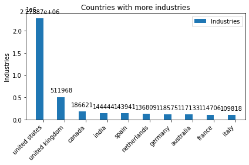

```python
labels = countries
x = np.arange(len(labels))
width = 0.35
fig, ax = plt.subplots()
rects = ax.bar(x - width/2, industries, width, label='Industries')
ax.set_ylabel('Industries')
ax.set_title('Countries with more industries')
ax.set_xticks(x)
ax.set_xticklabels(labels, rotation=45, ha='right')
ax.legend()
ax.bar_label(rects, padding=6)
fig.tight_layout()
```

Now, we can see countries by the mean_size of industries, descrescent:

```python
meanInd = pandasDfCountriesTotal.nlargest(10, 'mean_size')
countries = meanInd["Country"].tolist()
mean_size = meanInd["mean_size"].tolist()
table = vaex.from_arrays(countries = countries, mean_size = mean_size)
print(table)
```

```
  #  countries           mean_size
  0  micronesia           112.4
  1  grenada               71.6
  2  south korea           48.8686
  3  american samoa        42.5
  4  liechtenstein         41.6615
  5  saudi arabia          40.3256
  6  montserrat            37
  7  qatar                 36.0189
  8  papua new guinea      35.3786
  9  switzerland           33.4152
```

Wich can generate the following view:

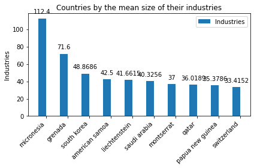

```python
labels = countries
x = np.arange(len(labels))
width = 0.35
fig, ax = plt.subplots()
rects = ax.bar(x - width/2, mean_size, width, label='Industries')
ax.set_ylabel('Industries')
ax.set_title('Countries by the mean size of their industries')
ax.set_xticks(x)
ax.set_xticklabels(labels, rotation=45, ha='right')
ax.legend()
ax.bar_label(rects, padding=6)
fig.tight_layout()
```

Now, we can see countries by the max_size of industries, descrescent:

```python
maxSizeInd = pandasDfCountriesTotal.nlargest(10, 'max_size')
countries = maxSizeInd["Country"].tolist()
max_size = maxSizeInd["max_size"].tolist()
table = vaex.from_arrays(countries = countries, max_size = max_size)
print(table)
```

```
  #  countries         max_size
  0  united states       274047
  1  india               190771
  2  ireland             190689
  3  united kingdom      158363
  4  germany              87381
  5  finland              84327
  6  france               84218
  7  sweden               67692
  8  netherlands          60324
  9  switzerland          58538
```

Wich can generate the following view:

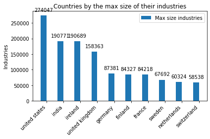

```python
labels = countries
x = np.arange(len(labels))
width = 0.35
fig, ax = plt.subplots()
rects = ax.bar(x - width/2, max_size, width, label='Max size industries')
ax.set_ylabel('Industries')
ax.set_title('Countries by the max size of their industries')
ax.set_xticks(x)
ax.set_xticklabels(labels, rotation=45, ha='right')
ax.legend()
ax.bar_label(rects, padding=6)
fig.tight_layout()
```

Now we will prepare some geovisualization. We will draw a map, with the color intensity representing the number of companies in each country. First, we will create two lists from data:

> - df_countries = list of countries to identify in map
> - Industries = list of all industries a country

```python
DfCountriesTotal = vaex.from_pandas(df=pandasDfCountriesTotal, copy_index=True)
df_countries = DfCountriesTotal["Country"].tolist()
Industries = DfCountriesTotal["Industry"].tolist()
```

And we feed them to Choropleth, a library that draws a map identifying each country and using the z as a measure of how intense the color painting the country will be. In this case, the stronger the color, the more industries the country has.

Chorpleth has very interesting features, wich we will further explore in other occasions. By now, we will mention that if you hover your cursor over the countries, it will show you the exact number of industries in it.

And here we can see the density of companies in the world:

```python
fig = go.Figure(data=go.Choropleth(
    locations = df_countries,
    locationmode = 'country names',
    z = Industries,
    colorscale = 'Reds',
    marker_line_color = 'black',
    marker_line_width = 0.5,
))
fig.show()
```

[interactive chart not shown]

Here we will see the same map, but removing United States of America, United Kingdom and Canada from the list, since they have disproportionately more industries.

```python
Industries.remove(max(Industries))
Industries.remove(max(Industries))
Industries.remove(max(Industries))
df_countries.remove("united states")
df_countries.remove("united kingdom")
df_countries.remove("canada")
```

```python
fig = go.Figure(data=go.Choropleth(
    locations = df_countries,
    locationmode = 'country names',
    z = Industries,
    colorscale = 'Reds',
    marker_line_color = 'black',
    marker_line_width = 0.5,
))
fig.show()
```

[interactive chart not shown]